# Analysis of Species Codes in TerrADat

Jason Karl

21 November, 2016

This document summarizes an analysis of species codes contained in the TerrADat database for AIM data from 2011 to 2015. This analysis was conducted in an attempt to understand the extent to which non-standardized plant codes are being used in AIM projects. Non-standard codes include plant codes (species and genus) that are not in the USDA PLANTS database and codes that follow the accepted AIM protocol for unknown plants.

The comparisons below were conducted by comparing the species recorded in the species inventory of an AIM plot to the USDA PLANTS database master list for North America (downloaded 11/16/2016). At this point an analysis of plant codes in LPI was not conducted under the assumption that the species inventory would also include any species identified in LPI.

Specific questions to be addressed here are:

1. What is the prevalence of unknown and non-standard plant codes by project?
2. Does the use of unknown and non-standard species codes vary by project and over time?
3. What are the most common custom codes for unknown plants that do not conform to AIM standards?
4. How prevalent is the use of “retired” plant codes (e.g., continuing to use AGSP instead of PSSP6)?

## 1. What is the prevalence of unknown and non-standard plant codes by project?

Percentage of all species in Species Inventory at the plot level* that were recorded with:

| Statistic | Official Unknown Plant Code | Plant Code not in PLANTS Database |
| --- | --- | --- |
| Average | 2.619108% | 6.3470159% |
| Minimum | 0% | 0% |
| Maximum | 53.3333333% | 100% |

*i.e., an unknown plant code value of 50% would mean that half of all the species in the species inventory were coded as unknown plants.

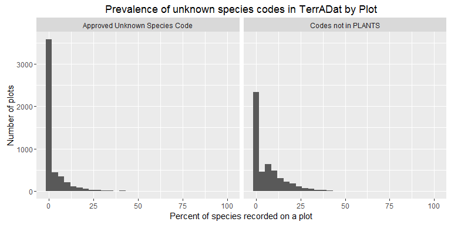

#### Number of plots on which plant species not in the master list were recorded by project area.

This list does not include legitimate unknown species codes.

| ProjectBase | n |
| --- | --- |
| California NorCal | 116 |
| Nevada EKDO | 112 |
| Nevada SNDO | 108 |
| Nevada Winnemucca ESR | 108 |
| Nevada CCDO | 96 |
| Washington Wenatchee FO | 77 |
| Colorado White River FO | 71 |
| Nevada WMDO | 60 |
| Nevada EYDO | 58 |
| Nevada BMDO | 50 |
| Wyoming Lander FO | 50 |
| Utah Grand Staircase Escalante NM | 29 |
| Alaska NPR-A | 23 |
| Idaho Bruneau FO | 20 |
| Idaho CRMONM AIM | 17 |
| Colorado Gunnison FO | 12 |
| California Riverside East SEZ | 10 |
| Arizona Agua Fria NM | 6 |
| California Applegate FO | 6 |
| Colorado Grand Junction FO | 3 |
| New Mexico RGdNNM | 3 |
| Colorado Tres Rios FO | 2 |
| California SurpriseFO ESR | 1 |
| Colorado San Luis Valley FO 2015 GUSG Ha | 1 |
| Colorado Uncompagre FO | 1 |

## 2. Does the use of non-standard species codes vary by project and over time?

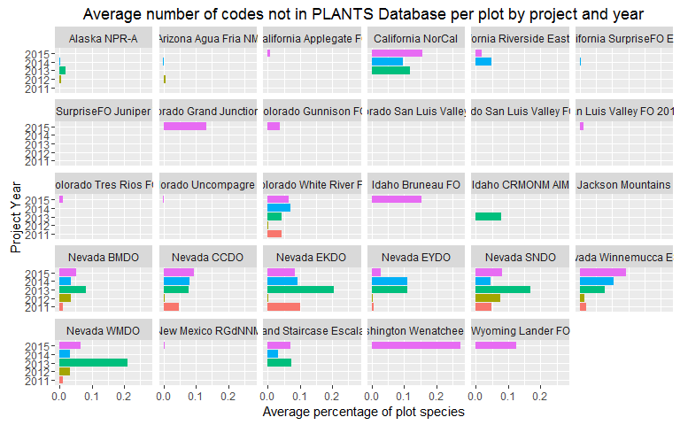

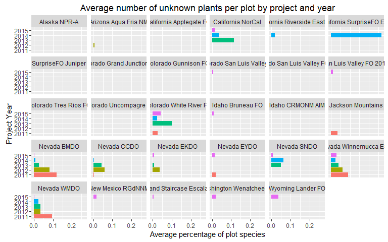

## 3. How prevalent are custom codes for unknown plants that do not conform to AIM standards?

#### 50 most common custom plant codes and the number of plots on which they were recorded.

| Code | numPlots |
| --- | --- |
| LUPINPF | 141 |
| ASTRAP | 102 |
| ASTRAPF | 98 |
| ERIOGPF | 97 |
| ERIGE2PF | 91 |
| LOMATPF | 83 |
| LUPINP | 78 |
| CREPIPF | 77 |
| PENSTPF | 76 |
| CRYPTA | 72 |
| CRYPTAF | 67 |
| PENSTP | 60 |
| L | 53 |
| CASTI2PF | 52 |
| LEPU | 46 |
| LOMATP | 44 |
| GILIAAF | 37 |
| WL | 36 |
| ERIOGP | 33 |
| AAFF | 32 |
| LEPIDA | 32 |
| ASTRAA | 32 |
| EPHEDSH | 31 |
| ALLIUPF | 30 |
| ARABI2PF | 29 |
| CREPIP | 28 |
| PHACEA | 26 |
| CHAENA | 26 |
| ERIOGAF | 26 |
| LOMATA | 24 |
| PPSH | 24 |
| PECTOA | 22 |
| ANTENPF | 22 |
| ERIGE2P | 21 |
| CALOCPF | 20 |
| CHNA2 | 20 |
| BOUTEA | 19 |
| PPFF | 19 |
| DELPHPF | 18 |
| ERIOGSH | 18 |
| ZIGADPF | 17 |
| ASTRAAF | 17 |
| CRYPTP | 16 |
| CHAENAF | 16 |
| ENCELP | 14 |
| LOMATAF | 14 |
| MENTZAF | 14 |
| ERIASAF | 13 |
| CASTI2P | 13 |
| OESU3 | 13 |

## 4. How prevalent is the use of “retired” plant codes (e.g., continuing to use AGSP instead of PSSP6)?

“Retired” plant codes can be found in the synonyms column of the PLANTS database table (or tblSpecies in DIMA). The table below lists the plants that were identified as not matching any current code in the PLANTS database but that do have an entry for a species synonym.

| Species.Code |
| --- |
| AGSI |
| AGSP |
| AGTR |
| AMALU |
| AQFOF3 |
| ARLUL |
| ARTRV2 |
| ARTRW |
| ASAD6 |
| ASGL3 |
| ASSC3 |
| ASTRA3 |
| BERE |
| BODR |
| BOLI6 |
| BOPA14 |
| BOST4 |
| BRAN13 |
| BRJA |
| CAAN |
| CANU14 |
| CECA11 |
| CHNA2 |
| CLSC2 |
| DESO |
| ELSM |
| ELSM3 |
| ERAS5 |
| ERCO24 |
| ERCOC13 |
| ERKIU |
| FOME |
| HANU2 |
| HESPM |
| HIJA |
| JUBA |
| KOAM |
| KONI |
| LALAL |
| LEPU |
| LIRU3 |
| LOPLA |
| LOTRP |
| MACA3 |
| MEAL2 |
| ORBA4 |
| ORHU2 |
| ORNI |
| PIMOF |
| POAG |
| PONE3 |
| RATE |
| SATR13 |
| SECA2 |
| SIAL11 |
| SISA7 |
| STCO3 |
| STJA3 |
| TUGL |

### Appendix A. List of plots with more than 25% of species were coded as Unknown or do not occur in the PLANTS database list

```
joining factor and character vector, coercing into character vectorjoining factor and character vector, coercing into character vector
```

#### Plots with more than 25% of species coded as Unknown

| ProjectBase | year | PlotID | TotalSpp | PctUnkn | PctNoMatch |
| --- | --- | --- | --- | --- | --- |
| California NorCal | 2013 | Bare 2 | 15 | 0.5333333 | 0.0000000 |
| California NorCal | 2014 | Twin Peaks 355 | 26 | 0.5000000 | 0.0000000 |
| California NorCal | 2013 | Muck Valley 3 | 22 | 0.5000000 | 0.0454545 |
| California NorCal | 2013 | D3-ARTRW 10 | 10 | 0.5000000 | 0.0000000 |
| California NorCal | 2013 | Bare 5 | 31 | 0.4516129 | 0.0967742 |
| California NorCal | 2013 | Bull Creek 5 | 9 | 0.4444444 | 0.0000000 |
| Colorado White River FO | 2013 | AL-7 | 7 | 0.4285714 | 0.0000000 |
| California NorCal | 2013 | Tuledad 9 | 21 | 0.4285714 | 0.0476190 |
| California NorCal | 2013 | Home Camp 2 | 31 | 0.4193548 | 0.1290323 |
| Colorado White River FO | 2013 | RS-9 | 12 | 0.4166667 | 0.0000000 |
| Colorado White River FO | 2013 | RS-9 | 12 | 0.4166667 | 0.0000000 |
| California NorCal | 2013 | Portuguese Flat 2 | 29 | 0.4137931 | 0.0344828 |
| Nevada BMDO | 2011 | Grass Valley 05 | 34 | 0.4117647 | 0.0000000 |
| California NorCal | 2013 | Stone 1 | 36 | 0.3888889 | 0.0833333 |
| California NorCal | 2013 | Portuguese Flat 1 | 27 | 0.3703704 | 0.0370370 |
| Nevada WMDO | 2013 | SM ICUA 01 | 30 | 0.3666667 | 0.1000000 |
| Nevada WMDO | 2013 | SM ICUA 01 | 30 | 0.3666667 | 0.1000000 |
| California NorCal | 2013 | Flournoy Individual 1 | 22 | 0.3636364 | 0.1818182 |
| California SurpriseFO ESR | 2014 | WCW B1 | 28 | 0.3571429 | 0.0000000 |
| California SurpriseFO ESR | 2014 | Denio N Burned 1 | 29 | 0.3448276 | 0.0000000 |
| California SurpriseFO ESR | 2014 | Denio N Unburned 1 | 29 | 0.3448276 | 0.0000000 |
| California NorCal | 2013 | Dry Valley 1 | 32 | 0.3437500 | 0.1562500 |
| Nevada Winnemucca ESR | 2012 | HSD-3 | 6 | 0.3333333 | 0.0000000 |
| California SurpriseFO ESR | 2014 | WCW UB1 | 15 | 0.3333333 | 0.0000000 |
| California NorCal | 2013 | Bend 1 | 30 | 0.3333333 | 0.0666667 |
| California NorCal | 2013 | Bare 4 | 18 | 0.3333333 | 0.1666667 |
| California NorCal | 2013 | Home Camp 6 | 27 | 0.3333333 | 0.1111111 |
| California NorCal | 2013 | Horse Lake 2 | 6 | 0.3333333 | 0.1666667 |
| California NorCal | 2013 | Mcdonald Mountain 1 | 29 | 0.3103448 | 0.0344828 |
| Nevada BMDO | 2012 | Roberts Mountain 24 | 13 | 0.3076923 | 0.0000000 |
| California NorCal | 2013 | Snowstorm 3 | 26 | 0.3076923 | 0.1538462 |
| California NorCal | 2013 | Massacre Mountain 3 | 13 | 0.3076923 | 0.0769231 |
| California NorCal | 2013 | Crooks Lake 2 | 33 | 0.3030303 | 0.1818182 |
| Nevada BMDO | 2012 | Santa Fe Ferguson 06 | 10 | 0.3000000 | 0.1000000 |
| California NorCal | 2013 | Wall Canyon West 4 | 30 | 0.3000000 | 0.2000000 |
| Nevada WMDO | 2012 | Granite Native 01 | 27 | 0.2962963 | 0.0370370 |
| California NorCal | 2013 | Mcdonald Mountain 2 | 24 | 0.2916667 | 0.0833333 |
| California NorCal | 2013 | New Bailey Creek 2 | 24 | 0.2916667 | 0.1666667 |
| Nevada CCDO | 2013 | Pine Nut PMU 35 | 14 | 0.2857143 | 0.0714286 |
| Nevada CCDO | 2013 | Pine Nut PMU 35 | 14 | 0.2857143 | 0.0714286 |
| Nevada WMDO | 2013 | SM ICUA 02 | 28 | 0.2857143 | 0.2500000 |
| Nevada WMDO | 2013 | SM ICUA 03 | 21 | 0.2857143 | 0.2380952 |
| Nevada CCDO | 2013 | Pine Nut PMU 35 | 14 | 0.2857143 | 0.0714286 |
| Nevada WMDO | 2013 | SM ICUA 02 | 28 | 0.2857143 | 0.2500000 |
| Nevada WMDO | 2011 | 5 Mile Native 02 | 21 | 0.2857143 | 0.0000000 |
| California NorCal | 2014 | Twin Peaks 210 | 14 | 0.2857143 | 0.0000000 |
| Colorado White River FO | 2014 | 21-12 | 14 | 0.2857143 | 0.0714286 |
| California NorCal | 2013 | Bare 7 | 14 | 0.2857143 | 0.0714286 |
| California NorCal | 2013 | Duck Lake 2 | 14 | 0.2857143 | 0.0714286 |
| Nevada WMDO | 2013 | SM ICUA 03 | 21 | 0.2857143 | 0.2380952 |
| California SurpriseFO ESR | 2014 | Bud Brown plot #3 | 18 | 0.2777778 | 0.0000000 |
| Nevada BMDO | 2013 | White Horse Basin Spring Excl | 40 | 0.2750000 | 0.0750000 |
| Nevada BMDO | 2011 | San Juan 07 | 11 | 0.2727273 | 0.0000000 |
| Colorado White River FO | 2013 | PJ-31 | 11 | 0.2727273 | 0.0000000 |
| Colorado White River FO | 2013 | PJ-31 | 11 | 0.2727273 | 0.0000000 |
| Colorado White River FO | 2013 | PJ-31 | 11 | 0.2727273 | 0.0000000 |
| California NorCal | 2013 | North Ash Valley 2 | 33 | 0.2727273 | 0.1515152 |
| California NorCal | 2013 | Sand Creek 1 | 11 | 0.2727273 | 0.0000000 |
| Nevada BMDO | 2011 | Home 05 | 23 | 0.2608696 | 0.0000000 |
| California NorCal | 2013 | Hogback 1 | 27 | 0.2592593 | 0.1111111 |
| Nevada WMDO | 2012 | Upper Crowley 01 | 27 | 0.2592593 | 0.0000000 |
| Nevada Winnemucca ESR | 2012 | HSD-2 | 4 | 0.2500000 | 0.0000000 |
| Nevada WMDO | 2011 | Coyote 01 | 8 | 0.2500000 | 0.0000000 |
| Nevada WMDO | 2011 | Idaho Canyon 01 | 16 | 0.2500000 | 0.0000000 |
| Nevada WMDO | 2011 | Big Creek 01 | 24 | 0.2500000 | 0.0416667 |
| Nevada WMDO | 2011 | Big Creek 02 | 20 | 0.2500000 | 0.0500000 |
| Nevada WMDO | 2011 | Coyote 01 | 8 | 0.2500000 | 0.0000000 |
| Nevada WMDO | 2011 | Idaho Canyon 01 | 16 | 0.2500000 | 0.0000000 |
| California NorCal | 2014 | Spanish Springs Ind 893 | 28 | 0.2500000 | 0.1428571 |
| Colorado White River FO | 2013 | AL-14 | 12 | 0.2500000 | 0.0833333 |
| Colorado White River FO | 2013 | AL-3 | 8 | 0.2500000 | 0.0000000 |
| California NorCal | 2013 | Wall Canyon West 5 | 28 | 0.2500000 | 0.1428571 |
| California NorCal | 2013 | Tuledad 7 | 4 | 0.2500000 | 0.0000000 |

#### Plots with more than 25% of species codes that do not occur in the PLANTS database

| ProjectBase | year | PlotID | TotalSpp | PctUnkn | PctNoMatch |
| --- | --- | --- | --- | --- | --- |
| Colorado Grand Junction FO | 2015 | 6613_8_F | 1 | 0.0000000 | 1.0000000 |
| Washington Wenatchee FO | 2015 | Carlton-13 | 36 | 0.0000000 | 0.5000000 |
| Nevada BMDO | 2015 | Romano 02 | 2 | 0.0000000 | 0.5000000 |
| California NorCal | 2013 | South Horse Lake 1 | 32 | 0.0312500 | 0.4687500 |
| California NorCal | 2013 | Crooks Lake 1 | 30 | 0.0333333 | 0.4666667 |
| Nevada BMDO | 2013 | Argenta 08 | 20 | 0.0000000 | 0.4500000 |
| Nevada EKDO | 2013 | Currie 07 | 14 | 0.0000000 | 0.4285714 |
| Washington Wenatchee FO | 2015 | Carlton-24 | 28 | 0.0357143 | 0.4285714 |
| Washington Wenatchee FO | 2015 | Colockum-38 | 19 | 0.0000000 | 0.4210526 |
| California NorCal | 2013 | Tule Mountain 1 | 39 | 0.0769231 | 0.4102564 |
| Washington Wenatchee FO | 2015 | R_Road-63 | 44 | 0.0681818 | 0.4090909 |
| Nevada EKDO | 2013 | Curtis Spring 02 | 20 | 0.0000000 | 0.4000000 |
| Nevada EKDO | 2013 | South Deeth 05 | 35 | 0.0000000 | 0.4000000 |
| California NorCal | 2013 | Bull Creek 3 | 28 | 0.0714286 | 0.3928571 |
| Nevada EYDO | 2013 | Forest Moon 01 | 18 | 0.0000000 | 0.3888889 |
| Nevada WMDO | 2013 | L 1 Revisit | 18 | 0.0000000 | 0.3888889 |
| California NorCal | 2013 | North Tablelands 1 | 31 | 0.0322581 | 0.3870968 |
| California NorCal | 2013 | Board Corral 1 | 13 | 0.0000000 | 0.3846154 |
| Washington Wenatchee FO | 2015 | Carlton-26 | 39 | 0.0000000 | 0.3846154 |
| Nevada EKDO | 2011 | Twenty-five Allotment 02 | 21 | 0.0000000 | 0.3809524 |
| California NorCal | 2013 | Home Camp 3 | 29 | 0.0000000 | 0.3793103 |
| Washington Wenatchee FO | 2015 | R_Road-64 | 37 | 0.0810811 | 0.3783784 |
| Washington Wenatchee FO | 2015 | Watermelon-68 | 45 | 0.0666667 | 0.3777778 |
| Nevada CCDO | 2013 | Lahontan 01 | 8 | 0.0000000 | 0.3750000 |
| Nevada WMDO | 2013 | BH BH 03 | 24 | 0.0000000 | 0.3750000 |
| Idaho Bruneau FO | 2015 | LowCM-131 | 16 | 0.0000000 | 0.3750000 |
| Nevada WMDO | 2013 | SM CUA 01 | 27 | 0.0000000 | 0.3703704 |
| Nevada WMDO | 2013 | SM CUA 01 | 27 | 0.0000000 | 0.3703704 |
| California NorCal | 2013 | North Horse Lake 1 | 27 | 0.0000000 | 0.3703704 |
| Nevada WMDO | 2013 | C 13 Revisit | 30 | 0.0333333 | 0.3666667 |

[output cut: 158 more lines]

This report was created with RMarkdown, which embeds the R code and results (stats, tables, graphs) in the document with the text. This is really cool.